# US Craft Beers and Breweries - EDA

Peter Phan & Sreeni Prabhala

1/12/2020

## Introduction

This project covers the details of exploratory analysis on US Craft Beers and Breweries data sets as requested by the Budweiser executive team. Our team did the required analysis on the data sets provided, and have consolidated answers for key questions, as well as interesting findings, in this project.

## Preparation

Import the beers and breweries data sets, remove any duplicates, and take a glimpse at them to make sure they are read successfully.

```
## Observations: 2,377
## Variables: 7
## $ Name       <fct> Pub Beer, Devil's Cup, Rise of the Phoenix, Siniste...
## $ Beer_ID    <int> 1436, 2265, 2264, 2263, 2262, 2261, 2260, 2259, 225...
## $ ABV        <dbl> 0.050, 0.066, 0.071, 0.090, 0.075, 0.077, 0.045, 0....
## $ IBU        <int> NA, NA, NA, NA, NA, NA, NA, NA, NA, NA, NA, NA, NA,...
## $ Brewery_id <int> 409, 178, 178, 178, 178, 178, 178, 178, 178, 178, 1...
## $ Style      <fct> American Pale Lager, American Pale Ale (APA), Ameri...
## $ Ounces     <dbl> 12.0, 12.0, 12.0, 12.0, 12.0, 12.0, 12.0, 12.0, 12....
```

```
## Observations: 558
## Variables: 4
## $ Brew_ID <int> 1, 2, 3, 4, 5, 6, 7, 8, 9, 10, 11, 12, 13, 14, 15, 16,...
## $ Name    <fct> NorthGate Brewing, Against the Grain Brewery, Jack's A...
## $ City    <fct> Minneapolis, Louisville, Framingham, San Diego, San Fr...
## $ State   <fct> MN, KY, MA, CA, CA, SC, CO, MI, MI, MI, MI, MI, MI, MI...
```

## Q1 : Where are the craft beer breweries located?

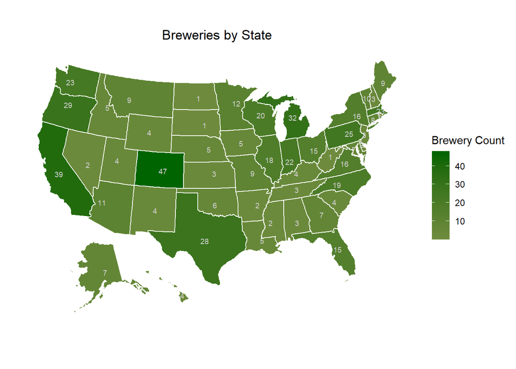

Most of the breweries are on the west coast, in Texas, and in more populous states on the east coast. The number of breweries in general seem to relate to the population of the state. A couple of interesting exceptions however - CO with 47 breweries and MI with 32 breweries seem to have more number of breweries than their population warrants.

## Q2 : Merge beer data with the breweries data. Print the first 6 and last 6 observations.

```
##   Brewery_Id     Beer_Name Beer_Id   ABV IBU
## 1          1  Get Together    2692 0.045  50
## 2          1 Maggie's Leap    2691 0.049  26
## 3          1    Wall's End    2690 0.048  19
## 4          1       Pumpion    2689 0.060  38
## 5          1    Stronghold    2688 0.060  25
## 6          1   Parapet ESB    2687 0.056  47
##                            Beer_Style Beer_OZ      Brewery_Name
## 1                        American IPA      16 NorthGate Brewing
## 2                  Milk / Sweet Stout      16 NorthGate Brewing
## 3                   English Brown Ale      16 NorthGate Brewing
## 4                         Pumpkin Ale      16 NorthGate Brewing
## 5                     American Porter      16 NorthGate Brewing
## 6 Extra Special / Strong Bitter (ESB)      16 NorthGate Brewing
##   Brewery_City Brewery_State
## 1  Minneapolis            MN
## 2  Minneapolis            MN
## 3  Minneapolis            MN
## 4  Minneapolis            MN
## 5  Minneapolis            MN
## 6  Minneapolis            MN
```

```
##      Brewery_Id                 Beer_Name Beer_Id   ABV IBU
## 2372        556             Pilsner Ukiah      98 0.055  NA
## 2373        557  Heinnieweisse Weissebier      52 0.049  NA
## 2374        557           Snapperhead IPA      51 0.068  NA
## 2375        557         Moo Thunder Stout      50 0.049  NA
## 2376        557         Porkslap Pale Ale      49 0.043  NA
## 2377        558 Urban Wilderness Pale Ale      30 0.049  NA
##                   Beer_Style Beer_OZ                  Brewery_Name
## 2372         German Pilsener      12         Ukiah Brewing Company
## 2373              Hefeweizen      12       Butternuts Beer and Ale
## 2374            American IPA      12       Butternuts Beer and Ale
## 2375      Milk / Sweet Stout      12       Butternuts Beer and Ale
## 2376 American Pale Ale (APA)      12       Butternuts Beer and Ale
## 2377        English Pale Ale      12 Sleeping Lady Brewing Company
##       Brewery_City Brewery_State
## 2372         Ukiah            CA
## 2373 Garrattsville            NY
## 2374 Garrattsville            NY
## 2375 Garrattsville            NY
## 2376 Garrattsville            NY
## 2377     Anchorage            AK
```

## Q3 : What’s the quality of data we have?

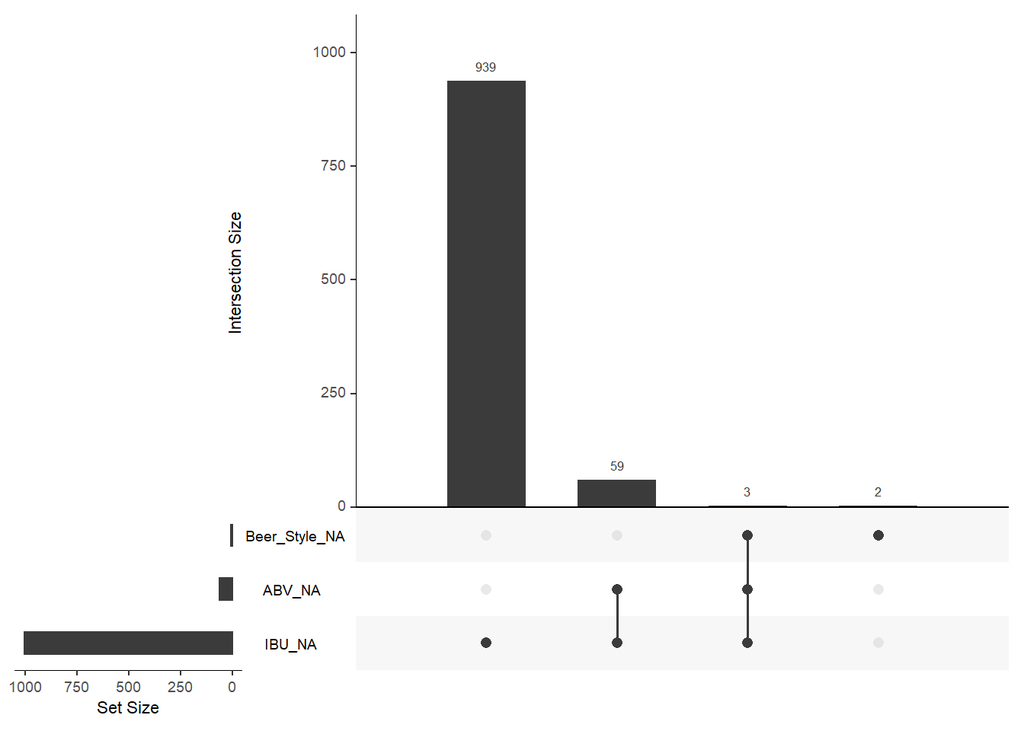

IBU value is missing in 42% of the observations. Few observations are missing values for ABV and/or Beer Style as well; however, they are not too concerning for our analyses. Let us look at the % missing of IBU values by State to see if the problem is limited to a few states.

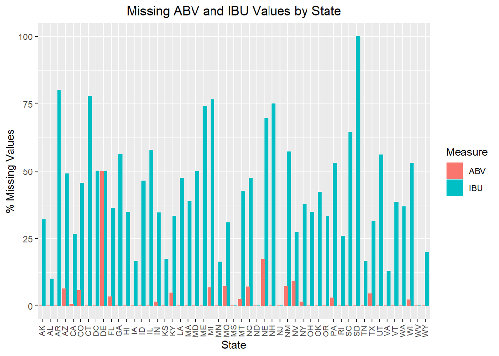

IBU values are missing across states; there are quite a few states or which more than 50% observations are missing IBU measure. SD is missing IBU measure for all observations. We will ignore observations with missing values for further analysis as applicable.

## Q4 : What are the median beer measures by State?

Let us look at summary of median measures to assess how we need to scale measures to depict them on same plot

```
##      State         ABV              IBU
##  AK     : 1   Min.   :0.0400   Min.   :19.00
##  AL     : 1   1st Qu.:0.0550   1st Qu.:30.00
##  AR     : 1   Median :0.0555   Median :35.00
##  AZ     : 1   Mean   :0.0559   Mean   :37.10
##  CA     : 1   3rd Qu.:0.0580   3rd Qu.:44.25
##  CO     : 1   Max.   :0.0625   Max.   :61.00
##  (Other):45                    NA's   :1
```

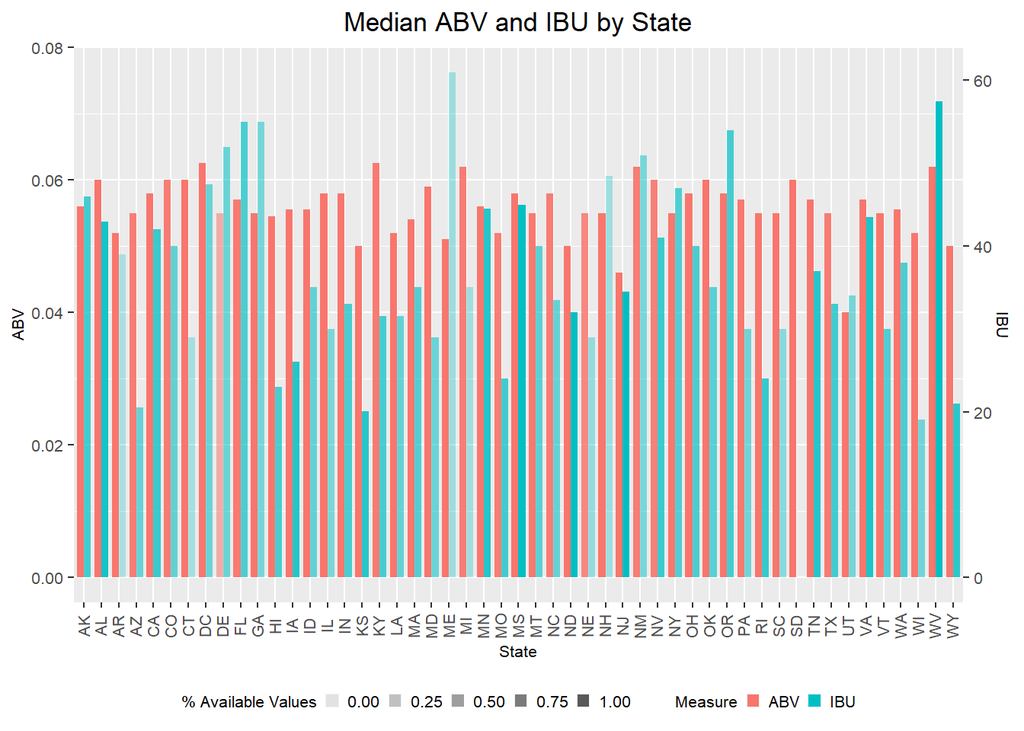

The variance of median IBU values across is more compared to the variance for median ABV values. The strength of the bar color represents our confidence in the median value reported for the state, given the missing values for measures. E.g. even though ME is depicted as having the highest median IBU value, we are not very confident on that measure as less than 25% of the ME observations have IBU value reported.

## Q5 : Which are our most strong and most bitter beers?

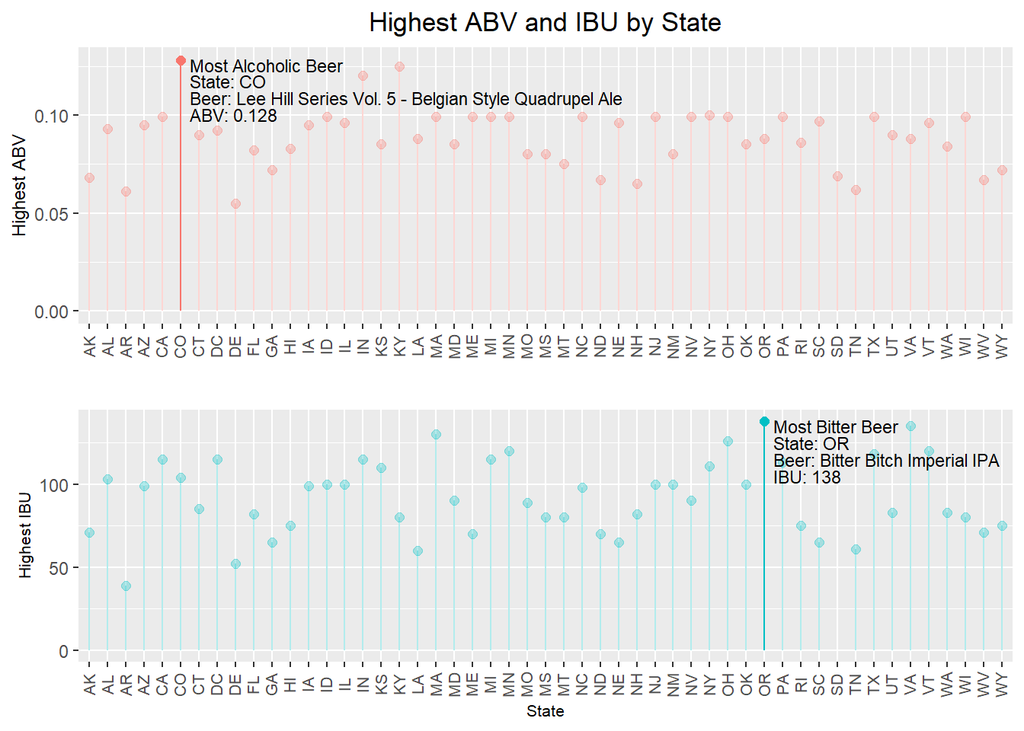

The highest ABV values for CO, IN, and KY seem to be outliers; they are significantly higher compared to the general range of highest ABV value for rest of the state (which are in he range 7.5% to 10%).

Again, variance of highest IBU values across states is more compared to the variance for highest ABV values, which is same as what we have found with median values.

## Q6 : What is the distribution of ABV of our beers?

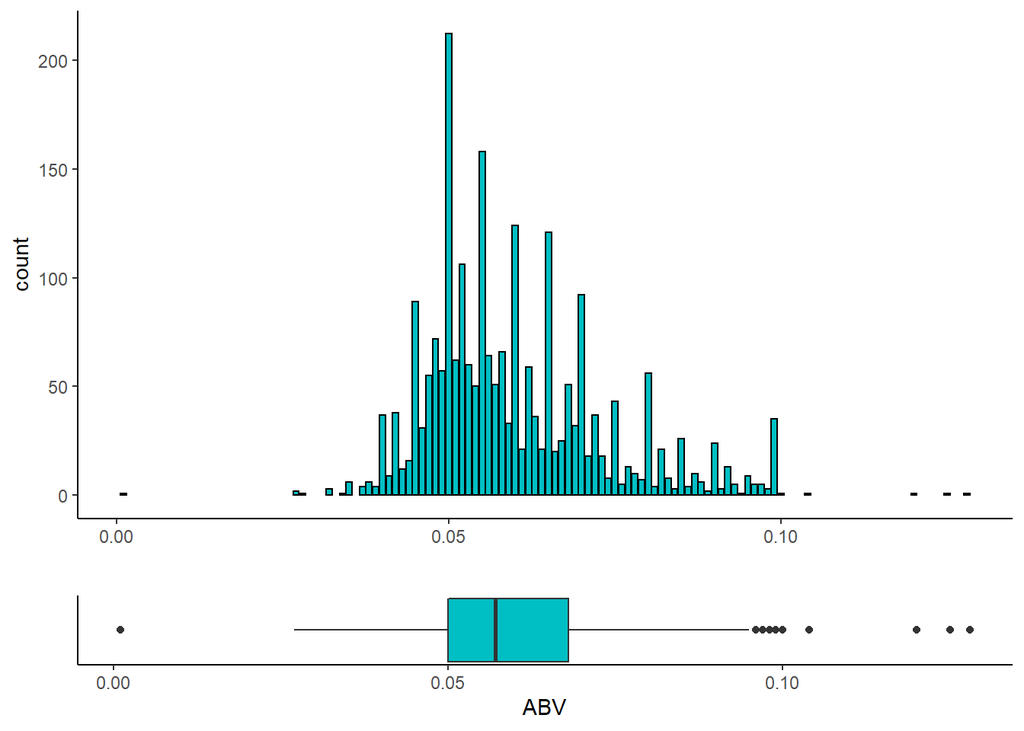

As discussed in the max. ABV plot, the box plot depicts the 3 outlier values CO, IN, and KY towards the right. Most of the beers have ABV value between 4% to 7% range. Given the outliers, median is still a good center measure to assess the distribution of ABV measure.

## Q7 : Is there a correlation between ABV and IBU?

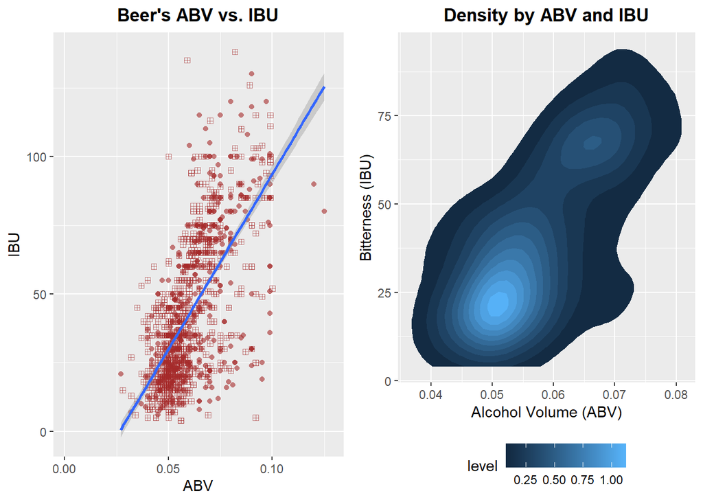

The scatterplot does depict a moderate positive correlation between ABV and IBU values - a beer with high ABV value is likely to have higher IBU value as well. However, we cannot establish causation - higher ABV value doesn’t cause higher IBU value.

## Q8 : Can we classify IPA and Other Ale beers using a KNN model based on ABV and IBU?

Look at summary of the data subset to assess variables and see if we need to normalize them to scale.

```
##       ABV             IBU         Ale_Category
##  Min.   :0.035   Min.   :  4.00   Length:924
##  1st Qu.:0.052   1st Qu.: 28.00   Class :character
##  Median :0.060   Median : 45.00   Mode  :character
##  Mean   :0.062   Mean   : 50.06
##  3rd Qu.:0.070   3rd Qu.: 70.00
##  Max.   :0.099   Max.   :138.00
```

Using the normalized variables, run KNN model for different values of k in 100 iterations with random train and test splits, and compute the mean accuracy. Calculate hyper parameter k value for highest accuracy.

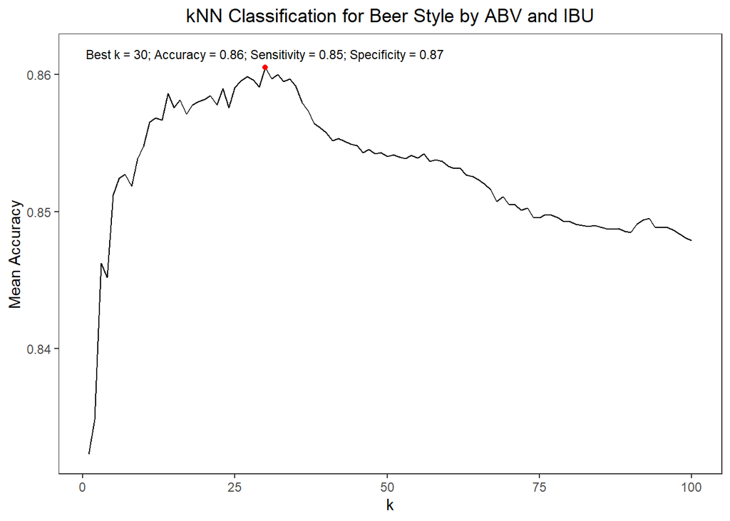

Using the KNN model based on ABV and IBU, we are getting greater than 85% accuracy in most cases. Our Sensitivity and Specificity statistics are are looking good. As such, this is a good model to classify beers into IPA and Other Ale categories.

## QA : Which states produce stronger beers on the average?

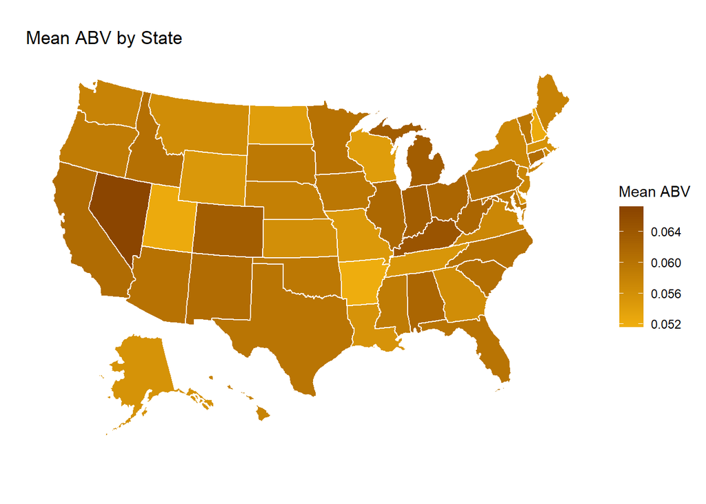

## QB : Are our breweries efficiently located across the US based on population and area? Are there opportunities to balance the consumption and production across states?

We will compare the percentage of breweries across states using a weighted percentage based on state’s population (based on 2019 census) and area (80:20 weightage).

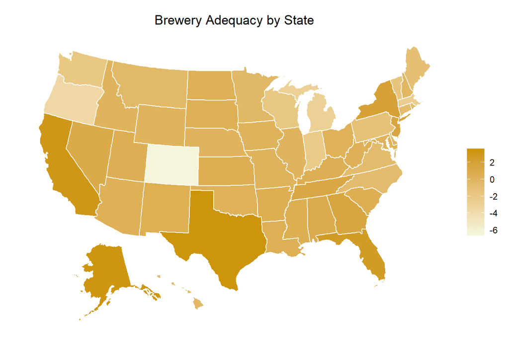

Based on the above, CA and TX, and to a lesser extent FL, NY, and NJ, may benefit from more number of breweries based on their population. CO seems to have way too many breweries for it’s population - if the inventory levels are maintained well at these breweries, it may not be a cause for concern.

The above analysis calls out AK as one of the states that can benefit from more breweries, but that inference is mostly based on AK’s huge size, and can be discarded as such.